# Oil x Envr (Final April Script)

KCF

4/6/2021

# Question 1

Do we observe evidence for spatially explicit selection on the percent of fatty acids in oil in wild sunflowers? To answer this question we’ll use the Qst-Fst to determine if there is evidence for non-neutral genotypic variation among populations. Qst will be estimated using a mixed effects model with the form:

Y ~ 1 + deme + (1|gr(Ind, A = G))

Qst = Va_deme / Va_deme + Va_Ind

Fst will be estimated on a per locus basis, and the Qst-Fst comparison will use the method suggested by Whitlock & Guillame (2008). Brielfy, that method of perfroms the Qst-Fst comparison by generating an empirical distribution of Qst values estimated from the genetic loci, and then compares the simulated distribution to the observed Qst estimate.

## Animal Model

Here is an outline of the steps in the Qst estimation protocol.

Step 1. Subset genotypes Step 2. Build a relatedness matrix from the SNPs Step 3. Build the animal model & record goodness of fit tests Step 4. Estimate Qst Step 5. Estimate Fst on a per locus basis Step 6. Simulate Qst values from each locus Step 7. Compare simulated Qst to observed value.

#### Read in the data

```r
# Read in the data
dat0 <- read.table("~/Dropbox/oil_envr/data/trait/oil_bioclim_ancestry_N153.txt",T,'\t')

# Read in the blocking effects
block <- read.table("~/Dropbox/oil_envr/data/block_effects/blocks.txt",T,'\t')

# Add the blocking effects
dat <- merge(dat0, block, by = "ind_code")

# Read in the snps as diploid, biallelic data
snps <- read.table("~/Dropbox/oil_envr/data/snps/snps.custom.genpop.txt",T,'\t')
```

View the overlap of genotypes with trait data.

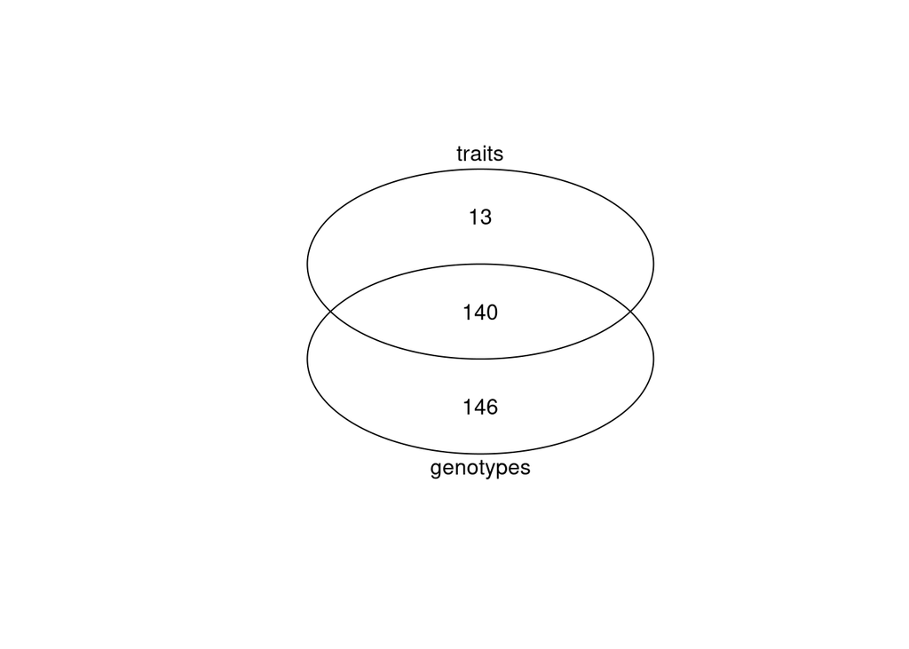

```r
l <- list(snps$ind_code, dat$ind_code)
names(l) <- c("genotypes", "traits")
overlap <- gplots::venn(l)
```

There are 140 individuals with trait and sequence data, 146 with only sequence data, and 13 with only trait data.

### Subset individuals

We have genotype data for 286 individuals and trait data for 153, and 140 inds have both snps and trait data. Subset genotypes and phenotypes for the common set.

```r
# Load tidyverse
library(tidyverse)
library(ggridges)

# List of inds to keep
keep <- attr(overlap,"intersections")$`genotypes:traits`

# Filter for snps
snps1 <- snps %>%
  filter(ind_code %in% keep) %>%
  arrange(ind_code)

# filter for phenotypes
dat1 <- dat %>%
  filter(ind_code %in% keep) %>%
  arrange(ind_code)
```

#### Build a relatedness matrix

Build a kinship matrix using the `Gmatrix` function from AGHmatrix. For details see `https://pubmed.ncbi.nlm.nih.gov/27902800/`. The first issue is filter the SNPs for the sites under selection according to McAseey. The Fst statistic is ideally built from neutral sites. Since, Ed already conducted an analyses with the SNPs to identify sites under selection, we should remove the 8 sites that show evidence of selection. See McAssey et al. 2016 for more details on the selection scan.

The second issue is I need to convert the data from it’s current format to 0, 1, 2, which is what Gmatrix expects. This can be done with tidyverse.

```r
# SNPs under selection to remove.
## It's not clear how to connect the results from McAssey to
## the locus names as I have them.
## I attempted to find the loci with the HA genome browswer to no avail.

## For now, just use all the snps.
## If you don't get significance from the Qst-Fst differences, you can
## talk to ed and see if he can help you figure out which 8 loci to
## remove. Otherwise, continue

# Convert the genotypes into 012 format
snps_agh <- snps1 %>%
  select(-ind_code) %>%
  mutate_all(
    funs(case_when(
      . == 11 ~ 0,
      . == 12 ~ 1,
      . == 21 ~ 1,
      . == 22 ~ 2
    ))
  )
# Replace missing sites with -9
snps_agh[is.na(snps_agh)] <- -9
```

```r
library(AGHmatrix)

# Computing the additive relationship matrix based on VanRaden 2008
G <- Gmatrix(SNPmatrix = as.matrix(snps_agh), missingValue=-9,
                  maf=0.05, method="VanRaden")
```

```
## Initial data:
##  Number of Individuals: 140
##  Number of Markers: 246
##
## Missing data check:
##  Total SNPs: 246
##   0 SNPs dropped due to missing data threshold of 1
##  Total of: 246  SNPs
## MAF check:
##   6 SNPs dropped with MAF below 0.05
##  Total: 240  SNPs
## Monomorphic check:
##  No monomorphic SNPs
## Summary check:
##  Initial:  246 SNPs
##  Final:  240  SNPs ( 6  SNPs removed)
##
## Completed! Time = 0.034  seconds
```

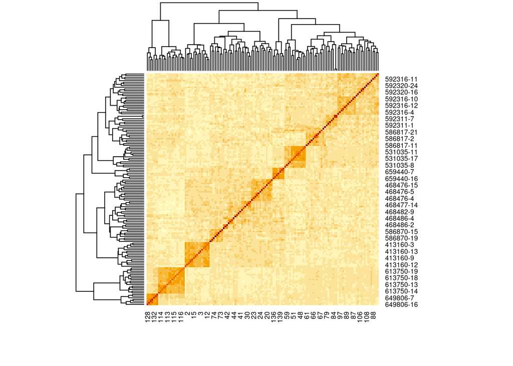

```r
# Set the row names
row.names(G) <- snps1$ind_code

# View the kinship matrix & save it
# The names need fixing up, (or turn them off & use population labels.)
heatmap(G)
```

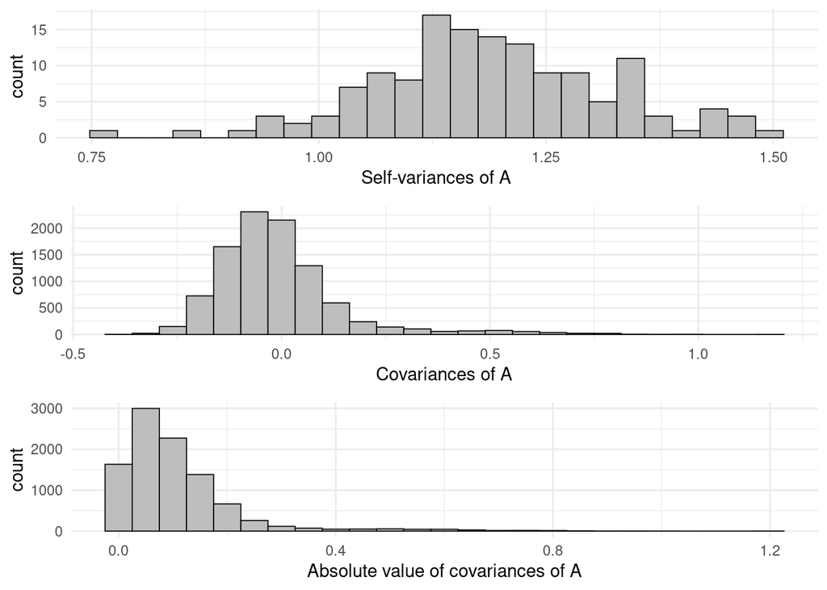

```r
# View a histogram of the self-variance components (the diagonal)
h0 <- ggplot(data.frame(V1=diag(G)), aes(x=V1))  +
  geom_histogram(bins = 25, color="black", fill="grey", lwd=0.3) +
  theme_minimal() +
  labs(x="Self-variances of A")

# View a histogram of the variance estimates.
h1 <- ggplot(data.frame(V1=G[upper.tri(G)]), aes(x=V1))  +
  geom_histogram(bins = 25, color="black", fill="grey", lwd=0.3) +
  theme_minimal() +
  labs(x="Covariances of A")

# Absolute value of covariance estimates
h2 <- ggplot(data.frame(V1=abs(G[upper.tri(G)])), aes(x=V1))  +
  geom_histogram(bins = 25, color="black", fill="grey", lwd=0.3) +
  theme_minimal() +
  labs(x="Absolute value of covariances of A")

# plot them together & save
pout <- cowplot::plot_grid(h0, h1, h2, ncol = 1, nrow = 3)
pout
```

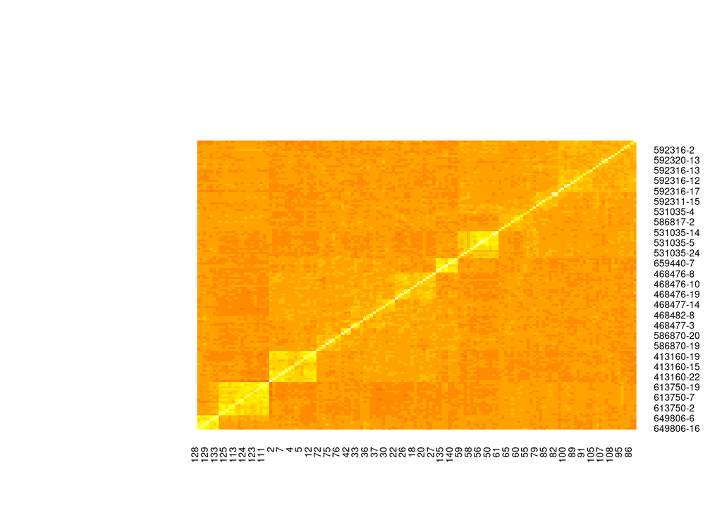

```r
#setwd("/Users/kf/Dropbox/oil_envr/results/kinship/figs")
#cowplot::save_plot(
#  filename = "Variance-Covariance_histograms_N140_v1.pdf",
#  plot = pout,
#  ncol = 1,
#  nrow = 1,
#  base_height = 6,
#  base_asp = 0.55,
#  base_width = NULL
#  )

# Combine the kinship matrix and the histograms into a single plot.
# You'll need to remake the kinship matrix with a ggplot2 function to combine
p0 <- cowplot::as_grob(gplots::heatmap.2(G, dendrogram = 'none',
                        Rowv=TRUE, Colv=TRUE, trace='none',
                        key = FALSE))
```

```r
# I think I need to make it in ggplot2 in order for it to work...
# This is relatively unimportant, work on it later
```

#### Fit the animal model

Now I can fit the animal model. Here are descriptions of the various model components:

- sat: % saturated fatty acids measred in oil.
- block: blocking effects of greenhouse experiment. Levels = 1:4
- deme: genetic populaitons (i.e. ‘demes’) estimated from SNP data with structure. Levels = north, south
- ind_code: individual ID of mother plants
  - G: genomic relatedness matrix estimated from SNP loci.

```r
library(brms)

qst_mod <- brm(sat ~ 1 + block + deme + (1|gr(ind_code, cov = G)),
                data = dat1,
                data2 = list(G = G),
                family = "gaussian",
                seed = 2398, chains = 4L, iter = 6000)
```

```r
load("/media/two_tb_A/Dropbox/oil_envr/results/brms/models/qst/qst_mod0.brms")

# View the model
qst_mod
```

```
##  Family: gaussian
##   Links: mu = identity; sigma = identity
## Formula: sat ~ 1 + block + deme + (1 | gr(ind_code, cov = G))
##    Data: dat1 (Number of observations: 140)
## Samples: 4 chains, each with iter = 6000; warmup = 3000; thin = 1;
##          total post-warmup samples = 12000
##
## Group-Level Effects:
## ~ind_code (Number of levels: 140)
##               Estimate Est.Error l-95% CI u-95% CI Rhat Bulk_ESS Tail_ESS
## sd(Intercept)     0.78      0.15     0.51     1.08 1.00     2413     4468
##
## Population-Level Effects:
##           Estimate Est.Error l-95% CI u-95% CI Rhat Bulk_ESS Tail_ESS
## Intercept     4.60      0.29     4.02     5.18 1.00     9648     8920
## block         0.10      0.10    -0.09     0.28 1.00    11657     9012
## demesouth     1.79      0.41     0.97     2.59 1.00     6827     7465
##
## Family Specific Parameters:
##       Estimate Est.Error l-95% CI u-95% CI Rhat Bulk_ESS Tail_ESS
## sigma     0.96      0.10     0.78     1.16 1.00     2552     4025
##
## Samples were drawn using sampling(NUTS). For each parameter, Bulk_ESS
## and Tail_ESS are effective sample size measures, and Rhat is the potential
## scale reduction factor on split chains (at convergence, Rhat = 1).
```

Here’s an alternative way to specify the model. I’m not yet sure why I would do this however…

```r
# This is a slightly different model where the effects of deme are a
# random effect and are a cofactor with the levels of ind_code
# Still not sure if this is correct
pop_mod4 <- brm(sat ~ 1 + block + (1 + deme|gr(ind_code, cov = G)),
                data = dat1,
                data2 = list(G = G),
                family = "gaussian",
                seed = 2398, chains = 4L, iter = 6000)
```

#### Estimate Qst

Qst is the proportion of additive genetic variance among populations to the total phenotypic variation. Since we fit a bayesian model, we have posterior samples to work with to estimate the median and confidence intervals of the median.

```r
# Pull out the posterior sample and square them.
# These are the variance components
out <- qst_mod %>%
  brms::posterior_samples(.vars=2:4, .funs=funs(.^2))

# Calculate Qst from the correct variance components.
qst = out$b_demesouth /
  (out$b_demesouth + out$b_block + 2 * out$sd_ind_code__Intercept)

# Print the median & interval estimates
tidybayes::median_qi(qst)
```

```
##           y      ymin     ymax .width .point .interval
## 1 0.5216696 0.3490208 0.650466   0.95 median        qi
```

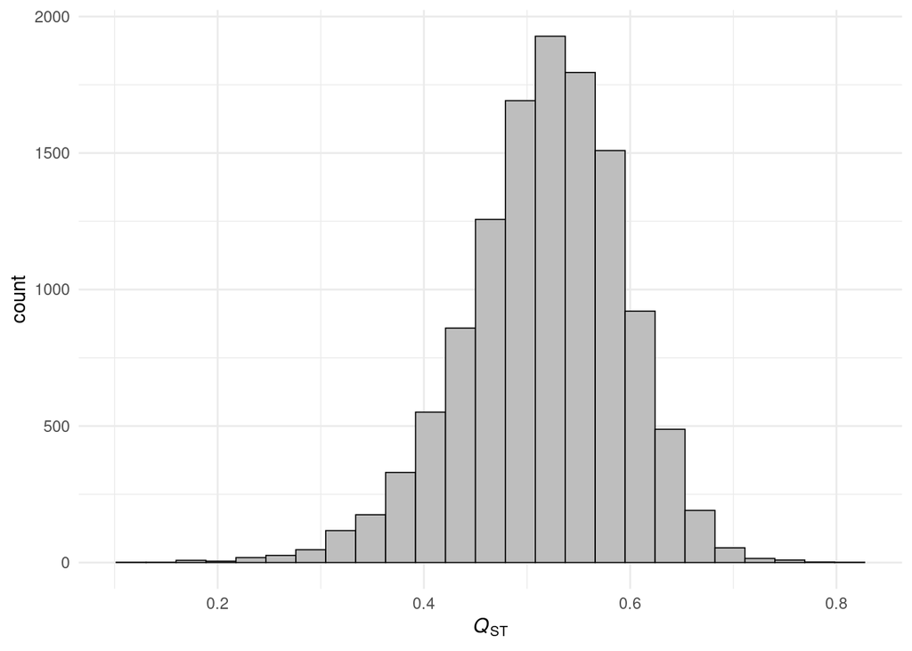

```r
# Plot the distribution
p1 <- ggplot(data.frame(Qst=qst), aes(x=Qst))  +
  geom_histogram(bins = 25, color="black", fill="grey", lwd=0.3) +
  theme_minimal() +
  labs(x=expression(paste(italic(Q)[ST])))
p1
```

```r
# This isn't working.
# Keep it moving and come back to this if you want it.
#ggplot(data.frame(Qst=qst), aes(x=Qst, fill = factor(stat(quantile)))) +
#  stat_density_ridges(
#    geom = "density_ridges_gradient",
#    calc_ecdf = TRUE,
#    quantiles = c(0.025, 0.975)
#  ) +
#  scale_fill_manual(
#    name = "Probability", values = c("#FF0000A0", "#A0A0A0A0", "#0000FFA0"),
#    labels = c("(0, 0.025]", "(0.025, 0.975]", "(0.975, 1]")
#  )

#setwd("~/Dropbox/oil_envr/results/qst/figs")
#cowplot::save_plot(
#  filename = "qst_values.qst_mod0.brms_6x3.pdf",
#  plot = p1,
#  ncol = 1,
#  nrow = 1,
#  base_height = 3,
#  base_asp = 2,
#  base_width = NULL
#  )
```

### Estimate h2

Narrow-sense heritabiity estimate.

```r
Va = out$sd_ind_code__Intercept
Vp = out$sd_ind_code__Intercept + out$sigma

tidybayes::median_qi(Va/Vp)
```

```
##           y      ymin      ymax .width .point .interval
## 1 0.4461891 0.3152081 0.5651231   0.95 median        qi
```

## Fst estimate

Ed previously estimated Fst to be 0.21 using all markers. He also performed an analysis where he identified 8 SNPs that show evidence of selection. I will estimate Fst with all SNPs and with the 8 non-neutral sites removed. I need to find a bayesian method for estimating Weir & Cockerham’s Fst.

```r
# Load the SNP data

# Estimate Fst as a two population model with multiple families.
# In this model deme = population and family = breeding population
```

## Compare Qst to Fst

How to do this? I think it’s simply a matter of comparing the two values and if they overlap. You can take the different and the 95% CI’s of the difference to, if the CI’s of the differences don’t overlap, you can take that as evidence of support.